# Day 1: 100 Days of Coding

## I asked ChatGPT to generate a 100 days of code challenge for R.

## —————————————————————————–

## Day 1:

Project: Write an R script to generate random data and create a basic plot

I will start with creating a dataframe of random data. I will use sample() to randomly sample from 1 to 1000 and will let a value be sampled more than once. I want to create a dataframe of 20 observations across two variables.

```r
data <- data.frame(Var1 = sample(1:1000, size = 20, replace = TRUE),
                   Var2 = sample(1:1000, size = 20, replace = TRUE))
```

I wanted the data to have a large range with 20 observations in each variable.

I will now examine the data:

```r
head(data)
```

|  | Var1 | Var2 |
| --- | --- | --- |
| 1 | 920 | 960 |
| 2 | 847 | 814 |
| 3 | 435 | 625 |
| 4 | 14 | 876 |
| 5 | 96 | 445 |
| 6 | 741 | 565 |

```r
summary(data)
```

```
      Var1            Var2
 Min.   : 14.0   Min.   : 33.0
 1st Qu.:270.2   1st Qu.:379.2
 Median :606.0   Median :528.5
 Mean   :551.0   Mean   :539.0
 3rd Qu.:793.0   3rd Qu.:725.5
 Max.   :967.0   Max.   :996.0
```

Now, to do a simple scatter plot, using Base-R, to explore the data:

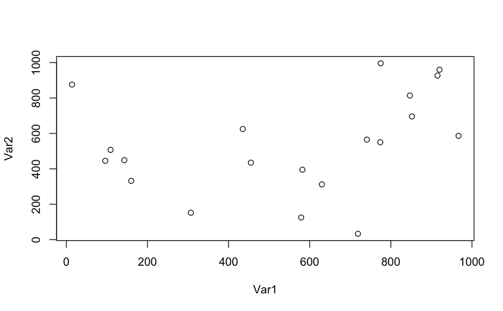

Now i want to explore the distribution of the data using a historgram:

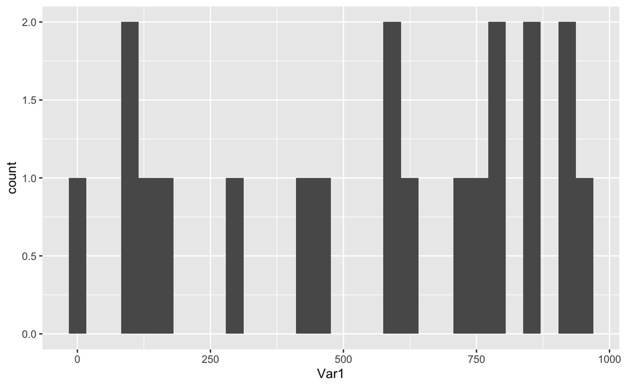

```r
library(ggplot2)
ggplot(data, aes(Var1)) +
  geom_histogram()
```

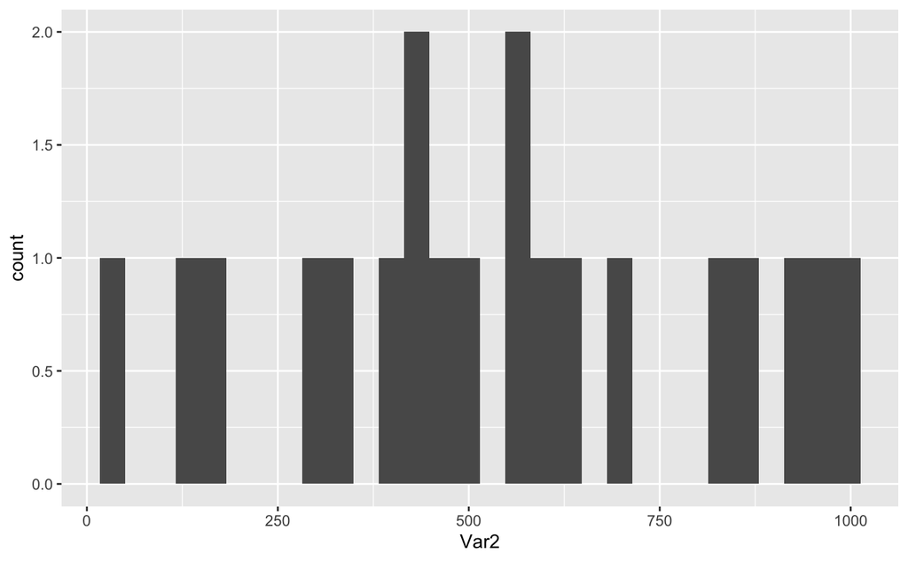

```r
ggplot(data, aes(Var2)) +
  geom_histogram()
```

Something that would be interesting to try would be to standardize the data:

```r
data$Var1 <- scale(data$Var1)
data$Var2 <- scale(data$Var2)
summary(data)
```

```
       Var1.V1              Var2.V1
 Min.   :-1.7051323   Min.   :-1.8117890
 1st Qu.:-0.8914635   1st Qu.:-0.5720025
 Median : 0.1746411   Median :-0.0375964
 Mean   : 0.0000000   Mean   : 0.0000000
 3rd Qu.: 0.7684209   3rd Qu.: 0.6677839
 Max.   : 1.3209219   Max.   : 1.6363390
```

I will now look at various plots for this data, starting with a scatter plot:

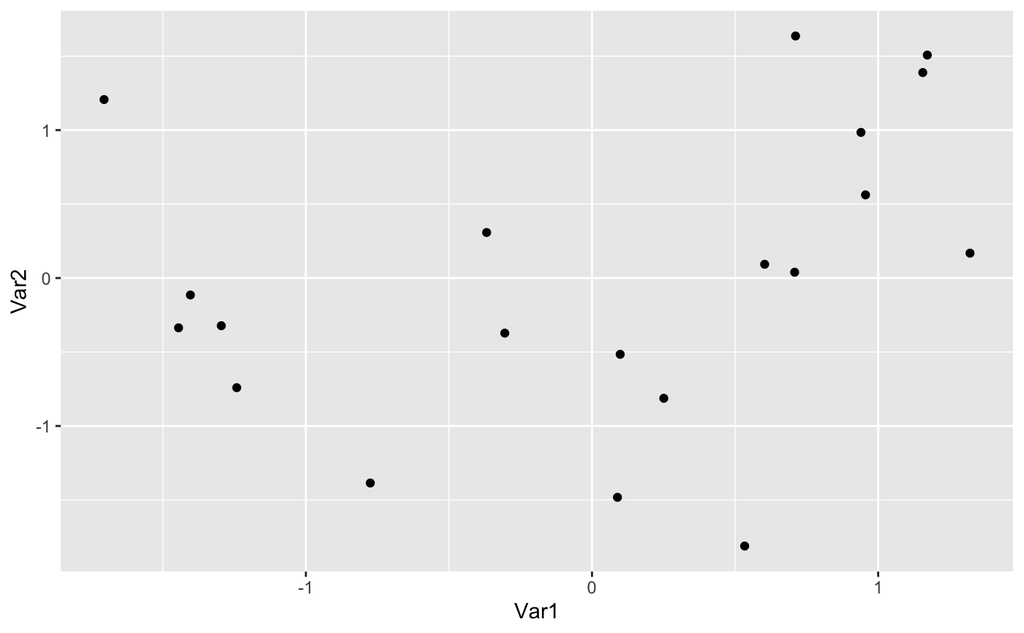

```r
ggplot(data, aes(Var1, Var2)) +
  geom_point()
```

Density plot for Var1

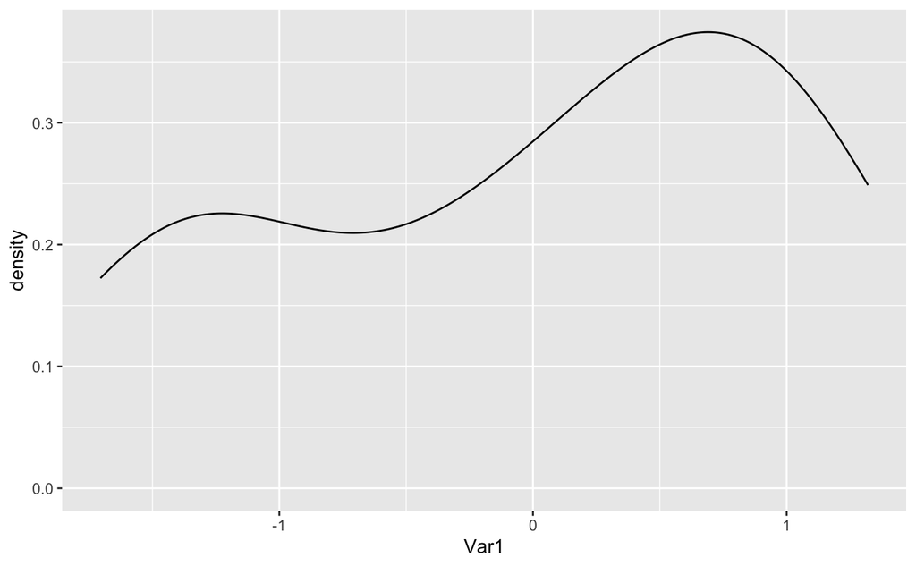

```r
ggplot(data, aes(Var1))+
  geom_density()
```

Density plot for Var2

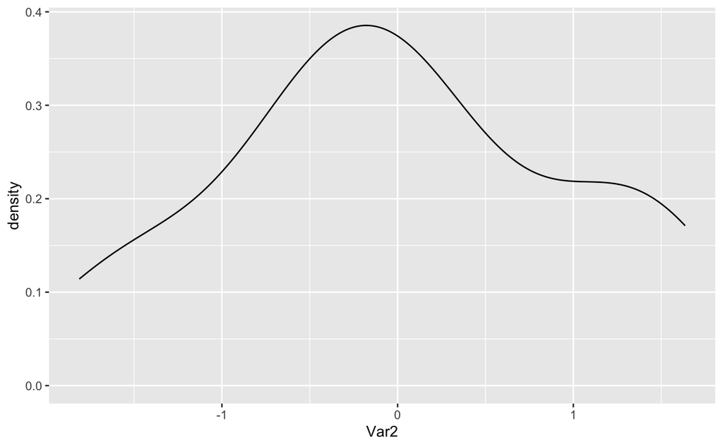

```r
ggplot(data, aes(Var2)) +
  geom_density()
```

This was a rather simple and easy exercise that incorporates: 1)generating random numbers for data and 2) plotting the data

This was a great warm-up to continue with the 100 days of coding.